# Movies on Netflix, Amazon Prime, Disney +, and Hulu

Archita Singh, Tyrell Garza, Enoch Lee

2/19/2021

## Introduction

When we think about watching movies in the modern world, especially during the pandemic, we think about watching from the comfort of our homes. The popularity of Netflix, Amazon Prime, Disney +, and Hulu has rocketed in recent years due to their convenience as well as the quality content they provide to users. Our team is curious about the difference among these 4 major platforms and what characteristics set them apart from each other.

Our data set contains information about the movies available on Netflix, Amazon Prime, Disney +, and Hulu and we found it on [Kaggle](https://www.kaggle.com/ruchi798/movies-on-netflix-prime-video-hulu-and-disney). We chose to work with this data set because it provides a wide range of information to work with, including everything from the directors to the countries the movies are available in. With the different types of data available, we were able to take a deeper look at what proportion of movies were intended for each age group, cross reference IMDb and Rotten Tomato ratings, and see the amount of movies on each streaming service.

## Table

We included the table because it provided insight to what the top 10 ranked IMDb movies out every movie streaming service, globally. We found that the highest rating was 9.3 and the lowest rating of was 9.0 for the top 10. We also found that the majority of the movies were from Hollywood.

| Title | IMDb |
| --- | --- |
| My Next Guest with David Letterman and Shah Rukh Khan | 9.3 |
| Love on a Leash | 9.3 |
| Square One | 9.3 |
| Steven Banks: Home Entertainment Center | 9.3 |
| Down, But Not Out! | 9.3 |
| Bounty | 9.3 |
| Natsamrat | 9.1 |
| Finding Family | 9.1 |
| Where’s Daddy? | 9.1 |
| The Dark Knight | 9.0 |

## Pie Chart

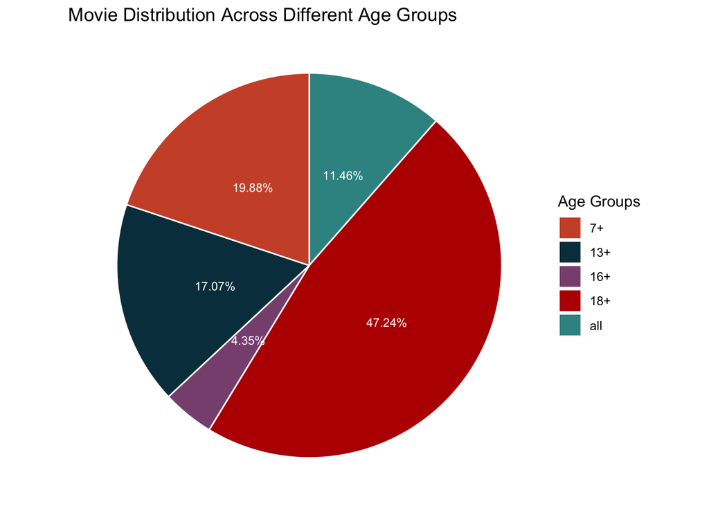

## Scatterplot

The scatterplot shows the relationship between the Rotten Tomatoes and IMDb ratings. We found that its much easier to get 100% on Rotten Tomatoes than a 10 on IMDb (0 movies have a 10). There is a noticeable difference between the high ratings on Rotten Tomatoes and the high ratings on IMDb. Many movies rated between 2.5 and 5 on IMDb got a rating of 60% and higher on Rotten Tomatoes. Our findings made us curious about the reliability of these sites and whether one was more accurate than the other.

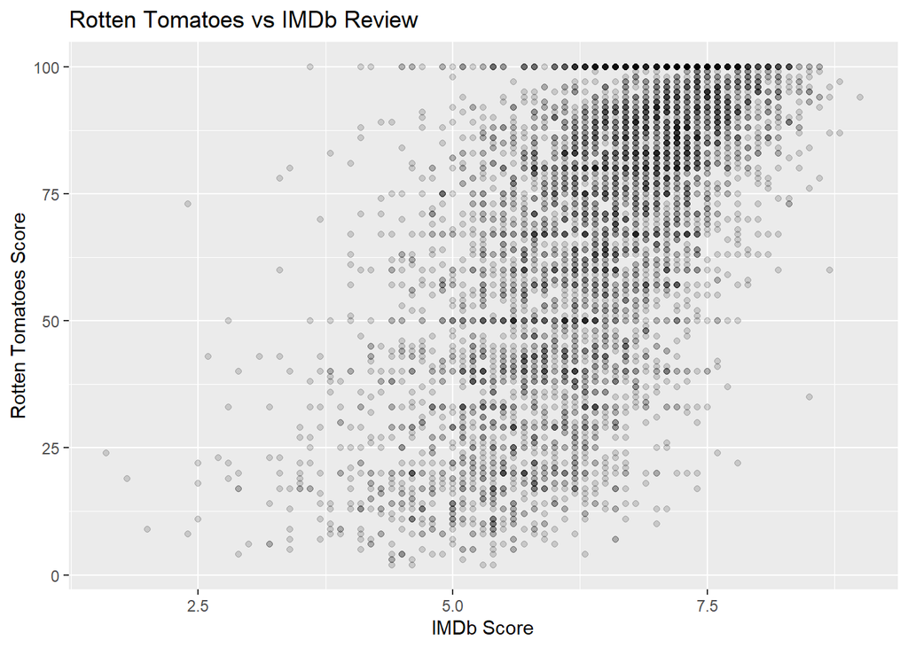

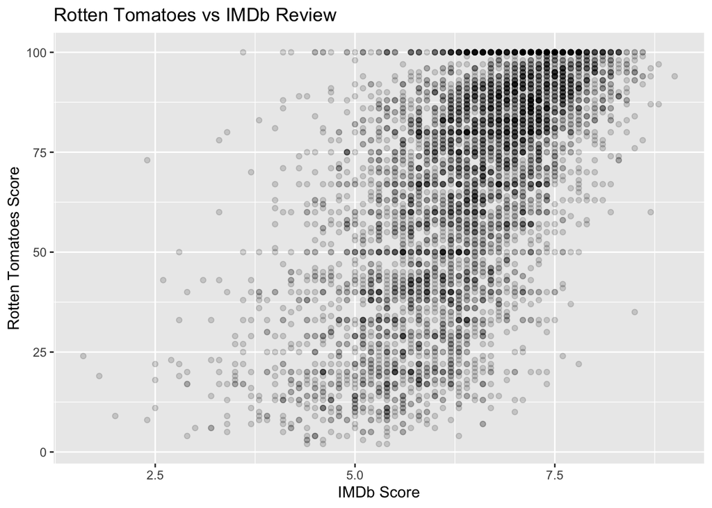

## Bar Graph

We created the histogram to represent the relationship between the different streaming platforms and the number of movies that were available. We wanted to find out what streaming services had the most movies within the data set. This provided us with better context regarding each feature, and a better understanding of the influence of each of the movie-streaming platforms. The data showed that Amazon Prime offered the most content by far, with Netflix, Hulu, and Disney trailing behind. We were surprised to see that Amazon Prime had more content than Netflix since Netflix has a massive name for itself and is often seen as the go-to streaming platform. Disney+ coming in last, on the other hand, made sense to us because it is limited to movies created by Disney/Disney owned companies.

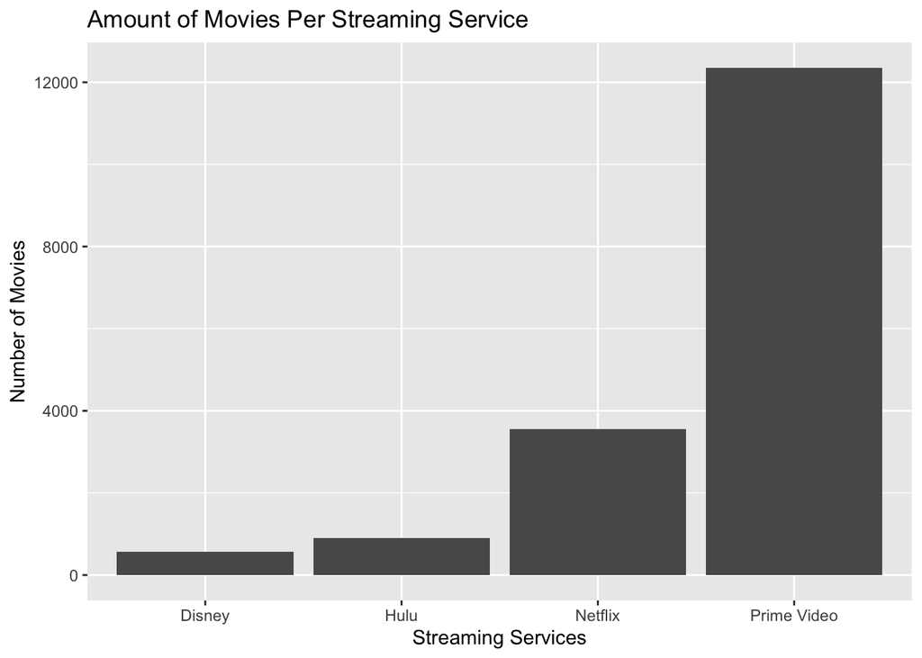